# MDS_HW2

## MDS Assignment 2

```python
#### import functions
%matplotlib inline
import matplotlib.pyplot as plt
import numpy as np
import pandas as pd
import seaborn as sns
import statsmodels.api as sm
from sklearn import linear_model
from sklearn.datasets import make_regression
```

#### Q1 - Stepwise Regression and Regularization- Ridge, Lasso, and Elastic Net

```python
#### import datasets
plant_df = pd.read_csv("MiningProcess_Flotation_Plant_Database.csv",decimal=',')
x = plant_df.drop(['% Silica Feed'], axis=1)

#### drop the date section cause it's not so important
x = plant_df.drop(['date'], axis=1)
y = plant_df[['% Silica Feed']]
```

###### Q1-A

Identify the important variable by linear regression with ordinary least squares (OLS) (i.e. ranked by p-value).

```python
X = sm.add_constant(x)
ols_model = sm.OLS(y,X)
ols_result = ols_model.fit()
print(ols_result.summary())
```

```
                            OLS Regression Results
==============================================================================
Dep. Variable:          % Silica Feed   R-squared:                       1.000
Model:                            OLS   Adj. R-squared:                  1.000
Method:                 Least Squares   F-statistic:                 2.794e+30
Date:                Thu, 11 Nov 2021   Prob (F-statistic):               0.00
Time:                        11:01:48   Log-Likelihood:             1.9563e+07
No. Observations:              737453   AIC:                        -3.913e+07
Df Residuals:                  737429   BIC:                        -3.913e+07
Df Model:                          23
Covariance Type:            nonrobust
================================================================================================
                                   coef    std err          t      P>|t|      [0.025      0.975]
------------------------------------------------------------------------------------------------
const                         1.823e-12   1.88e-13      9.697      0.000    1.45e-12    2.19e-12
% Iron Feed                  -9.447e-15   7.25e-16    -13.033      0.000   -1.09e-14   -8.03e-15
% Silica Feed                    1.0000   5.46e-16   1.83e+15      0.000       1.000       1.000
Starch Flow                  -2.045e-16   7.86e-19   -260.145      0.000   -2.06e-16   -2.03e-16
Amina Flow                    1.308e-18    1.4e-17      0.094      0.925   -2.61e-17    2.87e-17
Ore Pulp Flow                -3.457e-16   9.82e-17     -3.521      0.000   -5.38e-16   -1.53e-16
Ore Pulp pH                   2.949e-15   2.43e-15      1.212      0.226   -1.82e-15    7.72e-15
Ore Pulp Density             -8.821e-14   1.75e-14     -5.036      0.000   -1.23e-13   -5.39e-14
Flotation Column 01 Air Flow  2.186e-15   1.01e-16     21.662      0.000    1.99e-15    2.38e-15
Flotation Column 02 Air Flow -3.746e-15   5.88e-17    -63.736      0.000   -3.86e-15   -3.63e-15
Flotation Column 03 Air Flow  1.495e-15   1.11e-16     13.514      0.000    1.28e-15    1.71e-15
Flotation Column 04 Air Flow -2.776e-15   4.28e-16     -6.488      0.000   -3.62e-15   -1.94e-15
Flotation Column 05 Air Flow  5.699e-16   2.59e-16      2.202      0.028    6.27e-17    1.08e-15
Flotation Column 06 Air Flow  8.654e-16   5.88e-17     14.728      0.000     7.5e-16    9.81e-16
Flotation Column 07 Air Flow -9.306e-16   6.13e-17    -15.185      0.000   -1.05e-15   -8.11e-16
Flotation Column 01 Level     7.353e-17   1.11e-17      6.641      0.000    5.18e-17    9.52e-17
Flotation Column 02 Level    -2.403e-16   1.02e-17    -23.597      0.000    -2.6e-16    -2.2e-16
Flotation Column 03 Level    -1.303e-16   8.79e-18    -14.822      0.000   -1.47e-16   -1.13e-16
Flotation Column 04 Level     1.146e-16   1.33e-17      8.607      0.000    8.85e-17    1.41e-16
Flotation Column 05 Level    -2.475e-17   1.66e-17     -1.490      0.136   -5.73e-17     7.8e-18
Flotation Column 06 Level    -6.766e-17   1.27e-17     -5.312      0.000   -9.26e-17   -4.27e-17
Flotation Column 07 Level    -1.145e-16   1.57e-17     -7.305      0.000   -1.45e-16   -8.38e-17
% Iron Concentrate           -1.314e-16   1.33e-15     -0.099      0.921   -2.74e-15    2.48e-15
% Silica Concentrate          5.733e-16   1.33e-15      0.430      0.667   -2.04e-15    3.18e-15
==============================================================================
Omnibus:                     4178.038   Durbin-Watson:                   0.012
Prob(Omnibus):                  0.000   Jarque-Bera (JB):             4260.809
Skew:                          -0.181   Prob(JB):                         0.00
Kurtosis:                       3.087   Cond. No.                     7.64e+05
==============================================================================

Warnings:
[1] Standard Errors assume that the covariance matrix of the errors is correctly specified.
[2] The condition number is large, 7.64e+05. This might indicate that there are
strong multicollinearity or other numerical problems.
```

###### Q1-B

Identify the important variable by stepwise regression. (hint: you can select forward selection, backward elimination, or both)

- 我用的是 backward elimination,將重要變數一個一個刪除。因為變數總量不多，因此使用此方法。
- 重要的變數如下列所示
  - ['% Iron Feed', '% Silica Feed', 'Starch Flow', 'Flotation Column 02 Air Flow', 'Flotation Column 04 Air Flow', 'Flotation Column 05 Air Flow', 'Flotation Column 06 Air Flow', 'Flotation Column 02 Level', 'Flotation Column 04 Level', 'Flotation Column 05 Level', 'Flotation Column 06 Level']

```python
#### backward elimination
def backward_regression(y,X,initial_list=[],threshold_in=0.01,threshold_out = 0.05,verbose=False):
  included=list(X.columns)
  while True:
      changed=False
      model = sm.OLS(y, sm.add_constant(pd.DataFrame(X[included]))).fit()
      # use all coefs except intercept
      pvalues = model.pvalues.iloc[1:]
      worst_pval = pvalues.max() # null if pvalues is empty
      if worst_pval > threshold_out:
          changed=True
          worst_feature = pvalues.idxmax()
          included.remove(worst_feature)
          if verbose:
              print('Drop  with p-value '.format(worst_feature, worst_pval))
      if not changed:
          break
  return included

backward_regression(y,X)
```

```
['const',
 '% Iron Feed',
 '% Silica Feed',
 'Starch Flow',
 'Flotation Column 02 Air Flow',
 'Flotation Column 04 Air Flow',
 'Flotation Column 05 Air Flow',
 'Flotation Column 06 Air Flow',
 'Flotation Column 02 Level',
 'Flotation Column 04 Level',
 'Flotation Column 05 Level',
 'Flotation Column 06 Level']
```

###### Q1-C

Give a comparison between (a) and (b). The results are consistent?

###### Q1-D

From a methodology aspect, what’s the difference between Ridge regression and Lasso? Why does Lasso support the variables selection rather than ridge? (hint: answer with description or formulation. No computation needed.)

- 最主要的差異是 ： Lasso 為 Linear Regression 加上 L1，Ridge 為 Linear Regression 加上 L2。 L1 為 絕對值，而L2 則是有平方項的計算。
- 與Ridge模型最大的差別，就是Lasso會將不具影響力的變數迴歸係數變成0，等於可以自動化的進行變數篩選(Feature selection)。

###### Q1-e What’s the benefit to use the Elastic Net? (hint: answer with description or formulation. No computation needed.)

- Ridge會有系統的將干擾變數係數逼近0(但不會等於0)，而Lasso則會將較無影響力的變數係數變成0。
- 而Elastic Net則綜合上述兩者的優勢，同時兼顧有效的正規化過程以及變數挑選功能。

###### Q1-F

Identify the important variable by **ridge regression**.

```python
import warnings
warnings.filterwarnings("ignore")
```

```python
ridge_cv= linear_model.RidgeCV(alphas=10**np.linspace(10,-2,100)*0.5).fit(X, y)
X.columns[ridge_cv.coef_ [0]!= 0.]
```

```
Index(['% Iron Feed', '% Silica Feed', 'Starch Flow', 'Amina Flow',
       'Ore Pulp Flow', 'Ore Pulp pH', 'Ore Pulp Density',
       'Flotation Column 01 Air Flow', 'Flotation Column 02 Air Flow',
       'Flotation Column 03 Air Flow', 'Flotation Column 04 Air Flow',
       'Flotation Column 05 Air Flow', 'Flotation Column 06 Air Flow',
       'Flotation Column 07 Air Flow', 'Flotation Column 01 Level',
       'Flotation Column 02 Level', 'Flotation Column 03 Level',
       'Flotation Column 04 Level', 'Flotation Column 05 Level',
       'Flotation Column 06 Level', 'Flotation Column 07 Level',
       '% Iron Concentrate', '% Silica Concentrate'],
      dtype='object')
```

###### Q1-G

Identify the important variable by **lasso**.

```python
lasso_cv = linear_model.LassoCV(cv=5, random_state=0,max_iter=5000).fit(X, y)
X.columns[lasso_cv.coef_ != 0.]
```

```
Index(['% Silica Feed', 'Starch Flow', 'Amina Flow'], dtype='object')
```

###### Q1-H

Identify the important variable by **elastic net**.

```python
elas_model = linear_model.ElasticNet(random_state=0)
elas_result = elas_model.fit(X, y)
X.columns[elas_result.coef_ != 0.]
```

```
Index(['% Iron Feed', '% Silica Feed', 'Starch Flow',
       'Flotation Column 02 Air Flow', 'Flotation Column 02 Level',
       'Flotation Column 04 Level', 'Flotation Column 05 Level',
       'Flotation Column 07 Level'],
      dtype='object')
```

###### Q1-I

Give a comparison between (f), (g) and (h). The results are consistent?

- 結果不一致
  - Ridge 即使透過選取最佳alpha仍無法順利刪減重要變數，而 Lasso 則是選取較少變數。Elastic Net 得出的重要變數數量在 Lasso 與Ridge 之間。

###### Q1-J

What is “adaptive elastic net”? Why we need it? How to build it? Please simply describe or formulate it. (No computation needed.)

ANS:

- Adaptive elastic net 即多一個變數來調控正規化因子，有點類似 adaptive lasso 加上 elastic net 的形式
- 使用 adaptive elastic net，是為了減少在高維度產生的偽陽性，同時保持估計的準確性。
- $\hat{𝛽}(Adapnet) = (1+\frac{\lambda_2}{n})\{argmin ||y-Xβ||^2_2+λ_2||\beta||^2_2+\lambda^*_1\sum_{j=1}^p\hat{w_j}|\beta_j|\}$

參考資料 ：[Multi-step adaptive elastic-net: reducing false positives in high-dimensional variable selection](https://nanx.me/papers/msaenet.pdf)

###### Q1-K

Which columns are highly-correlated? Show the table of the coefficient estimation by using linear regression. Any multicollinearity problem?  
Ans:  
以 VIF 方法來找尋具有共線性之變數。首先將每個變數與其他變數算出$R^2$。以導數的方式判斷其大小，VIF越小其共線性越小。以下為其判斷依據。

- 1 — features are not correlated
- 1<VIF<5 — features are moderately correlated
- VIF>5 — features are highly correlated
- VIF>10 — high correlation between features and is cause for concern

如下所示，透過VIF的計算可看出有出現貢獻性。其中出現貢獻性的變數有：['% Iron Feed', '% Silica Feed', 'Flotation Column 01 Air Flow', 'Flotation Column 03 Air Flow']

參考資料 :[VIF 計算共線性](https://towardsdatascience.com/statistics-in-python-collinearity-and-multicollinearity-4cc4dcd82b3f)

[figure not shown]

```python
##### coef estimation
corr_mat = X.corr()
sns.heatmap(corr_mat, annot=True)
plt.show()
```

```python
from sklearn.linear_model import LinearRegression
def calculate_vif(df, features):
    vif, tolerance = {}, {}
    no_corr=[]
    mod_corr=[]
    high_corr=[]
    danger_corr=[]
    # all the features that you want to examine
    for feature in features:
        # extract all the other features you will regress against
        X = [f for f in features if f != feature]
        X, y = df[X], df[feature]
        # extract r-squared from the fit
        r2 = LinearRegression().fit(X, y).score(X, y)

        # calculate tolerance
        tolerance[feature] = 1 - r2
        # calculate VIF
        if(tolerance[feature]!=0):
          vif[feature] = 1/(tolerance[feature])
          if(vif[feature]==1):
            no_corr.append(feature)
          elif(vif[feature]>1 and vif[feature] <5):
            mod_corr.append(feature)
          elif(vif[feature]>5 and vif[feature] <=10):
            high_corr.append(feature)
          elif(vif[feature]>10):
            danger_corr.append(feature)

    # return VIF DataFrame
    print('Highly correlated and danger to cause :',danger_corr)
```

```python
feature=[]
for col in X.columns:
  feature.append(col)
calculate_vif(X, features=feature)
```

```
Highly correlated and danger to cause : ['% Iron Feed', '% Silica Feed', 'Flotation Column 01 Air Flow', 'Flotation Column 03 Air Flow']
```

###### Q1-l Is it possible to predict % Silica in Concentrate without using % Iron Concentrate column (as they are highly correlated)? Why? What’s the potential issue? How to address it?

ANS :

- 可以，使用VIF來計算得出，取任一變數來做計算都不會使其他的變數受到太多的影響。且不被捨棄的變數 VIF也有變小，因此顯示兩者的確有共線性的問題。
- 可能會遇到知問題：要選擇哪一個捨棄？
- 解決辦法：
  - 看兩者哪一捨棄使另一方的VIF變得較小來選擇
  - 看哪一項資料取得較容易，就捨棄另一方

```python
def cal_vif_only(df, features):
    vif, tolerance = {}, {}
    # all the features that you want to examine
    for feature in features:
        # extract all the other features you will regress against
        X = [f for f in features if f != feature]
        X, y = df[X], df[feature]
        # extract r-squared from the fit
        r2 = LinearRegression().fit(X, y).score(X, y)

        # calculate tolerance
        tolerance[feature] = 1 - r2
        # calculate VIF
        if(tolerance[feature] !=0):
          vif[feature] = 1/(tolerance[feature])
    # return VIF DataFrame
    return pd.DataFrame({'VIF': vif, 'Tolerance': tolerance})
```

```python
feature=[]
for col in X.columns:
  feature.append(col)
cal_vif_only(X, features=feature)
```

|  | VIF | Tolerance |
| --- | --- | --- |
| % Iron Feed | 19.382730 | 0.051592 |
| % Silica Feed | 19.190281 | 0.052110 |
| Starch Flow | 1.265008 | 0.790509 |
| Amina Flow | 2.249846 | 0.444475 |
| Ore Pulp Flow | 1.257692 | 0.795107 |
| Ore Pulp pH | 1.230011 | 0.813001 |
| Ore Pulp Density | 2.040303 | 0.490123 |
| Flotation Column 01 Air Flow | 12.387536 | 0.080726 |
| Flotation Column 02 Air Flow | 4.355503 | 0.229595 |
| Flotation Column 03 Air Flow | 13.831617 | 0.072298 |
| Flotation Column 04 Air Flow | 1.680867 | 0.594931 |
| Flotation Column 05 Air Flow | 1.228232 | 0.814178 |
| Flotation Column 06 Air Flow | 4.371471 | 0.228756 |
| Flotation Column 07 Air Flow | 4.281437 | 0.233566 |
| Flotation Column 01 Level | 2.917964 | 0.342705 |
| Flotation Column 02 Level | 2.362086 | 0.423355 |
| Flotation Column 03 Level | 2.436729 | 0.410386 |
| Flotation Column 04 Level | 2.070150 | 0.483057 |
| Flotation Column 05 Level | 2.733239 | 0.365866 |
| Flotation Column 06 Level | 1.816876 | 0.550395 |
| Flotation Column 07 Level | 2.457506 | 0.406917 |
| % Iron Concentrate | 3.071119 | 0.325614 |
| % Silica Concentrate | 3.119088 | 0.320607 |
| const | NaN | 0.000000 |

```python
feature_without_iron =[]
feature_without_silica =[]
for col in X.columns:
  if(col != '% Iron Concentrate'):
    feature_without_iron.append(col)

for col in X.columns:
  if(col != '% Silica Concentrate'):
    feature_without_silica.append(col)
```

```python
#### no iron
cal_vif＿only(X, features=feature_without_iron)
```

|  | VIF | Tolerance |
| --- | --- | --- |
| % Iron Feed | 19.308038 | 0.051792 |
| % Silica Feed | 19.067294 | 0.052446 |
| Starch Flow | 1.264962 | 0.790538 |
| Amina Flow | 2.240249 | 0.446379 |
| Ore Pulp Flow | 1.244340 | 0.803639 |
| Ore Pulp pH | 1.213003 | 0.824401 |
| Ore Pulp Density | 2.024852 | 0.493863 |
| Flotation Column 01 Air Flow | 12.376466 | 0.080799 |
| Flotation Column 02 Air Flow | 4.343482 | 0.230230 |
| Flotation Column 03 Air Flow | 13.827715 | 0.072319 |
| Flotation Column 04 Air Flow | 1.677632 | 0.596078 |
| Flotation Column 05 Air Flow | 1.212931 | 0.824449 |
| Flotation Column 06 Air Flow | 4.366734 | 0.229004 |
| Flotation Column 07 Air Flow | 4.276755 | 0.233822 |
| Flotation Column 01 Level | 2.914904 | 0.343064 |
| Flotation Column 02 Level | 2.360857 | 0.423575 |
| Flotation Column 03 Level | 2.434460 | 0.410769 |
| Flotation Column 04 Level | 2.070135 | 0.483060 |
| Flotation Column 05 Level | 2.731243 | 0.366134 |
| Flotation Column 06 Level | 1.815128 | 0.550925 |
| Flotation Column 07 Level | 2.454572 | 0.407403 |
| % Silica Concentrate | 1.180511 | 0.847091 |
| const | NaN | 0.000000 |

```python
cal_vif＿only(X, features=feature_without_silica)
```

|  | VIF | Tolerance |
| --- | --- | --- |
| % Iron Feed | 19.339838 | 0.051707 |
| % Silica Feed | 19.095353 | 0.052369 |
| Starch Flow | 1.263912 | 0.791194 |
| Amina Flow | 2.240292 | 0.446370 |
| Ore Pulp Flow | 1.253552 | 0.797733 |
| Ore Pulp pH | 1.229232 | 0.813516 |
| Ore Pulp Density | 2.039963 | 0.490205 |
| Flotation Column 01 Air Flow | 12.330512 | 0.081100 |
| Flotation Column 02 Air Flow | 4.350980 | 0.229833 |
| Flotation Column 03 Air Flow | 13.829683 | 0.072308 |
| Flotation Column 04 Air Flow | 1.680784 | 0.594960 |
| Flotation Column 05 Air Flow | 1.221274 | 0.818817 |
| Flotation Column 06 Air Flow | 4.371455 | 0.228757 |
| Flotation Column 07 Air Flow | 4.278349 | 0.233735 |
| Flotation Column 01 Level | 2.914525 | 0.343109 |
| Flotation Column 02 Level | 2.361104 | 0.423531 |
| Flotation Column 03 Level | 2.436302 | 0.410458 |
| Flotation Column 04 Level | 2.069775 | 0.483144 |
| Flotation Column 05 Level | 2.732683 | 0.365941 |
| Flotation Column 06 Level | 1.816037 | 0.550649 |
| Flotation Column 07 Level | 2.456862 | 0.407023 |
| % Iron Concentrate | 1.162356 | 0.860322 |
| const | NaN | 0.000000 |

#### Q2 - Principal Component Analysis (PCA)- Faulty Steel Plates

```python
#### load datasets
names_df = pd.read_table("http://archive.ics.uci.edu/ml/machine-learning-databases/00198/Faults27x7_var",names=['colname'])
name=[]
for i in names_df['colname']:
  name.append(i)
plate_df = pd.read_table("http://archive.ics.uci.edu/ml/machine-learning-databases/00198/Faults.NNA",names=name)
```

```python
plate_df.head(10)
```

|  | X_Minimum | X_Maximum | Y_Minimum | Y_Maximum | Pixels_Areas | X_Perimeter | Y_Perimeter | Sum_of_Luminosity | Minimum_of_Luminosity | Maximum_of_Luminosity | Length_of_Conveyer | TypeOfSteel_A300 | TypeOfSteel_A400 | Steel_Plate_Thickness | Edges_Index | Empty_Index | Square_Index | Outside_X_Index | Edges_X_Index | Edges_Y_Index | Outside_Global_Index | LogOfAreas | Log_X_Index | Log_Y_Index | Orientation_Index | Luminosity_Index | SigmoidOfAreas | Pastry | Z_Scratch | … |
| --- | --- | --- | --- | --- | --- | --- | --- | --- | --- | --- | --- | --- | --- | --- | --- | --- | --- | --- | --- | --- | --- | --- | --- | --- | --- | --- | --- | --- | --- | --- |
| 0 | 42 | 50 | 270900 | 270944 | 267 | 17 | 44 | 24220 | 76 | 108 | 1687 | 1 | 0 | 80 | 0.0498 | 0.2415 | 0.1818 | 0.0047 | 0.4706 | 1.0000 | 1.0 | 2.4265 | 0.9031 | 1.6435 | 0.8182 | -0.2913 | 0.5822 | 1 | 0 | … |
| 1 | 645 | 651 | 2538079 | 2538108 | 108 | 10 | 30 | 11397 | 84 | 123 | 1687 | 1 | 0 | 80 | 0.7647 | 0.3793 | 0.2069 | 0.0036 | 0.6000 | 0.9667 | 1.0 | 2.0334 | 0.7782 | 1.4624 | 0.7931 | -0.1756 | 0.2984 | 1 | 0 | … |
| 2 | 829 | 835 | 1553913 | 1553931 | 71 | 8 | 19 | 7972 | 99 | 125 | 1623 | 1 | 0 | 100 | 0.9710 | 0.3426 | 0.3333 | 0.0037 | 0.7500 | 0.9474 | 1.0 | 1.8513 | 0.7782 | 1.2553 | 0.6667 | -0.1228 | 0.2150 | 1 | 0 | … |
| 3 | 853 | 860 | 369370 | 369415 | 176 | 13 | 45 | 18996 | 99 | 126 | 1353 | 0 | 1 | 290 | 0.7287 | 0.4413 | 0.1556 | 0.0052 | 0.5385 | 1.0000 | 1.0 | 2.2455 | 0.8451 | 1.6532 | 0.8444 | -0.1568 | 0.5212 | 1 | 0 | … |
| 4 | 1289 | 1306 | 498078 | 498335 | 2409 | 60 | 260 | 246930 | 37 | 126 | 1353 | 0 | 1 | 185 | 0.0695 | 0.4486 | 0.0662 | 0.0126 | 0.2833 | 0.9885 | 1.0 | 3.3818 | 1.2305 | 2.4099 | 0.9338 | -0.1992 | 1.0000 | 1 | 0 | … |
| 5 | 430 | 441 | 100250 | 100337 | 630 | 20 | 87 | 62357 | 64 | 127 | 1387 | 0 | 1 | 40 | 0.6200 | 0.3417 | 0.1264 | 0.0079 | 0.5500 | 1.0000 | 1.0 | 2.7993 | 1.0414 | 1.9395 | 0.8736 | -0.2267 | 0.9874 | 1 | 0 | … |
| 6 | 413 | 446 | 138468 | 138883 | 9052 | 230 | 432 | 1481991 | 23 | 199 | 1687 | 0 | 1 | 150 | 0.4896 | 0.3390 | 0.0795 | 0.0196 | 0.1435 | 0.9607 | 1.0 | 3.9567 | 1.5185 | 2.6181 | 0.9205 | 0.2791 | 1.0000 | 1 | 0 | … |
| 7 | 190 | 200 | 210936 | 210956 | 132 | 11 | 20 | 20007 | 124 | 172 | 1687 | 0 | 1 | 150 | 0.2253 | 0.3400 | 0.5000 | 0.0059 | 0.9091 | 1.0000 | 1.0 | 2.1206 | 1.0000 | 1.3010 | 0.5000 | 0.1841 | 0.3359 | 1 | 0 | … |
| 8 | 330 | 343 | 429227 | 429253 | 264 | 15 | 26 | 29748 | 53 | 148 | 1687 | 0 | 1 | 150 | 0.3912 | 0.2189 | 0.5000 | 0.0077 | 0.8667 | 1.0000 | 1.0 | 2.4216 | 1.1139 | 1.4150 | 0.5000 | -0.1197 | 0.5593 | 1 | 0 | … |
| 9 | 74 | 90 | 779144 | 779308 | 1506 | 46 | 167 | 180215 | 53 | 143 | 1687 | 0 | 1 | 150 | 0.0877 | 0.4261 | 0.0976 | 0.0095 | 0.3478 | 0.9820 | 1.0 | 3.1778 | 1.2041 | 2.2148 | 0.9024 | -0.0651 | 1.0000 | 1 | 0 | … |

###### Q2-A

Use the Logistic Regression to predict the defect type “Bumps” in the testing dataset. That is, only consider the Bumps column in the 7 defect types. What’s the accuracy and confusion matrix?  
ANS:

- accuracy : 0.784
- confusion matrix 如下圖

```python
##### 切割資料集
from sklearn.model_selection import train_test_split
X = plate_df.drop(['Bumps'], axis=1)
y = plate_df[['Bumps']]
x_train, x_test, y_train, y_test = train_test_split(X, y, test_size=0.25, random_state=0)
```

```python
#### logistic regression , using train_test split
from sklearn.linear_model import LogisticRegression
from sklearn import metrics
bump_model = LogisticRegression().fit(x_train, y_train)
predictions = bump_model.predict(x_test)
score = bump_model.score(x_test, y_test)
cm = metrics.confusion_matrix(y_test, predictions)
```

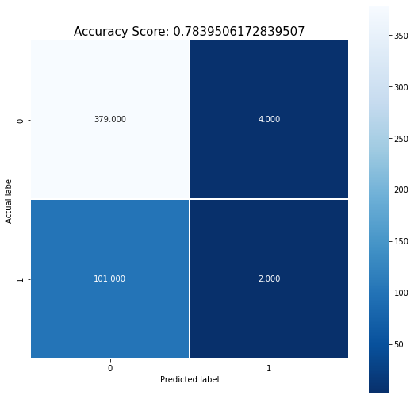

```python
#### plot
plt.figure(figsize=(9,9))
sns.heatmap(cm, annot=True, fmt=".3f", linewidths=.5, square = True, cmap = 'Blues_r');
plt.ylabel('Actual label');
plt.xlabel('Predicted label');
all_sample_title = 'Accuracy Score: {0}'.format(score)
plt.title(all_sample_title, size = 15);
```

#### Q2-B

For PCA, which variables should not be put into the PCA analysis (eg. binary variable).  
ANS : 二元宇相依變數應該要被捨棄。因此可以捨棄下列這些變數。

```python
c = X.columns[X.isin([0,1]).all()]
print (c)
```

```
Index(['TypeOfSteel_A300', 'TypeOfSteel_A400', 'Pastry', 'Z_Scratch',
       'K_Scatch', 'Stains', 'Dirtiness', 'Other_Faults'],
      dtype='object')
```

#### Q2-C

What’s eigenvalues and eigenvectors of covariance matrix in PCA? How can you interpret from these eigenvalues?  
ANS : 我們應該要取用那些特徵值大於1的值，來做計算。

```python
from sklearn.decomposition import PCA
pca_model = PCA().fit(X,y)
print(f"eigen vector : {np.array2string(pca_model.components_, formatter={'float': lambda x: f'{x:.2f}'})}")
print(f"eigen value : {np.array2string(pca_model.explained_variance_, formatter={'float': lambda x: f'{x:.2f}'})}")
```

```
eigen vector : [[0.00 0.00 0.71 ... -0.00 0.00 -0.00]
 [-0.00 -0.00 -0.00 ... -0.00 -0.00 -0.00]
 [0.09 0.06 -0.14 ... 0.00 0.00 0.00]
 ...
 [0.00 -0.00 -0.00 ... 0.01 0.00 -0.00]
 [-0.00 0.00 -0.00 ... -0.00 -0.00 -0.00]
 [-0.00 0.00 0.00 ... 0.00 0.00 -0.00]]
eigen value : [6298313578587.95 262455436938.87 1265930.17 462372.82 18864.78 13833.46
 2798.80 2579.37 752.99 686.87 153.21 63.22 0.53 0.35 0.26 0.20 0.08 0.07
 0.05 0.04 0.04 0.03 0.03 0.02 0.01 0.01 0.01 0.00 0.00 0.00 0.00 0.00
 0.00]
```

#### Q2-D

Plot a scree plot and decide the most appropriate number of principal components (PCs) to use.  
ANS : 最適合解釋此模型的變數數量為 0-5 之間

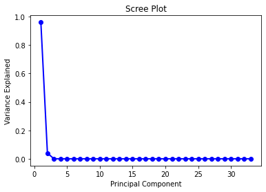

```python
PC_values = np.arange(pca_model.n_components_) + 1
plt.plot(PC_values, pca_model.explained_variance_ratio_, 'o-', linewidth=2, color='blue')
plt.title('Scree Plot')
plt.xlabel('Principal Component')
plt.ylabel('Variance Explained')
plt.show()
```

#### Q2-E

Use the selected PCs and perform Logistic Regression to predict the defect type “Bumps” again. What’s the accuracy and confusion matrix?

```python
pca_x = X[['X_Minimum','X_Maximum','Y_Minimum','Y_Maximum',	'Pixels_Areas']]
pca_x.head(10)
```

|  | X_Minimum | X_Maximum | Y_Minimum | Y_Maximum | Pixels_Areas |
| --- | --- | --- | --- | --- | --- |
| 0 | 42 | 50 | 270900 | 270944 | 267 |
| 1 | 645 | 651 | 2538079 | 2538108 | 108 |
| 2 | 829 | 835 | 1553913 | 1553931 | 71 |
| 3 | 853 | 860 | 369370 | 369415 | 176 |
| 4 | 1289 | 1306 | 498078 | 498335 | 2409 |
| 5 | 430 | 441 | 100250 | 100337 | 630 |
| 6 | 413 | 446 | 138468 | 138883 | 9052 |
| 7 | 190 | 200 | 210936 | 210956 | 132 |
| 8 | 330 | 343 | 429227 | 429253 | 264 |
| 9 | 74 | 90 | 779144 | 779308 | 1506 |

```python
new_pca_model = LogisticRegression().fit(pca_x,y)
new_pred = new_pca_model.predict(pca_x)
new_score = new_pca_model.score(pca_x, y)
new_cm = metrics.confusion_matrix(y, new_pred)
```

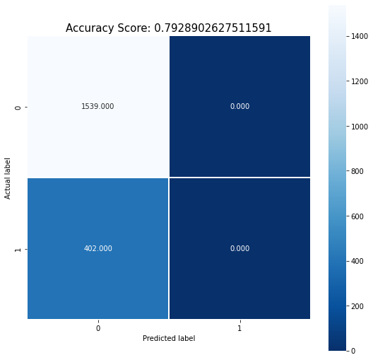

```python
#### plot
plt.figure(figsize=(9,9))
sns.heatmap(new_cm, annot=True, fmt=".3f", linewidths=.5, square = True, cmap = 'Blues_r');
plt.ylabel('Actual label');
plt.xlabel('Predicted label');
all_sample_title = 'Accuracy Score: {0}'.format(new_score)
plt.title(all_sample_title, size = 15);
```